# Exploratory Data Analysis

Bruno Santos & Antonio Paez

2025-03-20

# Introduction

This Rmarkdown file is part of the [**CommuteCA**](https://github.com/dias-bruno/CommuteCA) package. This package was created in conjunction with the office of the [*Research Data Center* at *McMaster University*](https://rdc.mcmaster.ca/), the [*Sherman Centre for Digital Scholarship*](https://scds.ca/) and the [*Mobilizing Justice*](https://mobilizingjustice.ca/).

The Mobilizing Justice project is a multidisciplinary and multi-sector collaboration with the objective of understand and address transportation poverty in Canada and to improve the well-being of Canadians at risk of transport poverty. The Social Sciences and Humanities Research Council (SSRHC) has provided funding for the project, which was created by an unprecedented alliance of academics from various Canadian provinces and institutions, transportation firms, and nonprofit organizations

The [**CommuteCA**](https://github.com/dias-bruno/CommuteCA) R package was created to develop standardized methods for transport analysis in research, particularly for analysis using the [*2021 Census of Population*](https://www12.statcan.gc.ca/census-recensement/index-eng.cfm) from Statistics Canada. We focused our efforts on the [*Commuting Reference Guide*](https://www12.statcan.gc.ca/census-recensement/2021/ref/98-500/011/98-500-x2021011-eng.cfm), which provides valuable variables and information on commuting for the Canadian population aged 15 and older living in private households.

This R markdown aims to provide a brief introduction to exploratory data analysis (EDA). This notebook is an updated and reduced version of the computational notebooks available in the [*edashop*](https://paezha.github.io/edashop/) package. The *edashop* package is an open educational resource to teach a workshop on EDA using R and computational notebooks, created and maintained by Dr. Antonio Paez, co-author of the *CommuteCA* package. For those interested in learning EDA in more deep, we suggest installing and studying the *edashop* package.

In this first R markdown, we will learn about:

- Descriptive statistics
- Visualization techniques

# Preliminaries

Clear the workspace from *all* objects:

```r
rm(list = ls())
```

Load packages. Remember, packages are units of shareable code that augment the functionality of base `R`. For this session, the following packages are used:

```r
library(corrr) # Correlations in R
library(dplyr) # A Grammar of Data Manipulation
library(janitor) # Simple Tools for Examining and Cleaning Dirty Data
library(ggplot2) # Create Elegant Data Visualizations Using the Grammar of Graphics
library(ggridges) # Ridgeline Plots in 'ggplot2'
library(readr) # Read csv files
library(skimr) # Summary statistics about variables in data frames
library(here) # enable easy file referencing in project-oriented workflows
```

We will also load the following data frames for this session. The dataset used in this demonstration is test data produced to replicate the variables available in the original Census of Population. The test data contains 200,000 rows and 17 columns. As in the original census data, each row refers to a respondent and each column refers to a variable.  
The creation of test data was necessary because the surveys provided by Statistics Canada are confidential and cannot be accessed outside of a Research Data Center.

You can check out more information about the Census on the [Dictionary website](https://www12.statcan.gc.ca/census-recensement/2021/ref/dict/index-eng.cfm).

If you want to work with the original Census dataset, the process for performing exploratory data analysis will be the same as for the test data, except that you will have to update the address of the file in the chunk called *load-census-data*.

A code chunk is an executable part of the R code.

For this R markdown, we’ll use the following variables:

The explanation of each variable can be found in the [*2021 Census of Population’s website*](https://www12.statcan.gc.ca/census-recensement/index-eng.cfm).

| **Variable** | **Description** |
| --- | --- |
| PRCDDA | Refers to the dissemination area (DA) of current residence. |
| Pr | Refers to the province or territory of current residence. |
| CMA | Census metropolitan area or census agglomeration of current residence. |
| PCD | Census division of current residence. |
| CompW1 | Weight for the households and dwellings universes. |
| LBR_FORC | This variable refers to whether a person was employed, unemployed or not in the labour force. |
| CfInc | Total income of census family (sum of the total incomes of all members of that family). |
| CFCNT | Census family size (numbers of persons). |
| CF_PnCF_NumEarners | Number of earners in census family. |
| PWDA | Place of work dissemination area. |
| PWPR | Place of work province. |
| PWCMA | Census metropolitan area or census agglomeration of place of work. |
| PWCD | Place of work census division. |
| PWDUR | Commuting duration, it refers to the length of time, in minutes, usually required by a person to travel to their place of work. |
| PWDist | Distance (straight-line) from home to work. |
| PwMode | Main mode of commuting’ refers to the main mode of transportation a person uses to travel to their place of work. |

We will use the function `read_csv()`to read the sheets in the format .csv . This is one of the format used by Research Data Centres to store their surveys.

``Other formats also used are:`SAS`,`Stata`and`SPSS`. For this case, use the {[foreign](https://cran.r-project.org/web/packages/foreign/index.html)} package.

The next chunk assigns the file address of the survey to the `census_address` variable. As mentioned before, for this demonstration we will use the test version of the survey. If you want to use the original survey, please remember to *update* the address in the chunk below. You may also need to update the file address if you opened this R markdown in another project or if the test data is stored in a different folder that does not follow the pattern of the `COMMUCECA21` package.

```r
census_address <- paste0(here::here(), "/data-raw/DA/input/test/census_test_v3.csv")
census <- read_csv(census_address)
```

Or if you have installed *CommuteCA*, you can access the test data by running:

```r
#data(census_test_data)
#census <- census_test_data
```

⚠️**NOTE:** If the code above did not run correctly, you probably are experiencing a file address error. Try to identify the correct address and update the chunk named `census-file-address` to continue.

# Exploratory Data Analysis (EDA)

Exploratory Data Analysis (EDA) involves examining data to uncover its inherent features without relying on preconceived assumptions. [John W. Tukey](https://en.wikipedia.org/wiki/John_Tukey) described EDA as detective work, where the goal is to discover key evidence and patterns before testing hypotheses, similar to the confirmation of evidence in a trial.

Effective EDA focuses on:

1. Simplifying descriptions for better cognitive processing.
2. Exploring deeper aspects of the data to enhance understanding.

The primary tools for EDA are descriptive statistics and visualization techniques, with a particular focus on using appropriate descriptors for different types of data.

# Descriptive statistics

In the previous session we used the function `summary()` from base `R` to obtain quick summaries of data. These summaries already provided some key information about the data, including descriptive statistics. For example, for our census table we have:

We use a variable named `selected_columns` to selected some columns in the census survey. This is needed because, if you are using the original census survey, the full table summary can be very slow and will require a lot of RAM from your computer.

```r
selected_columns <-c("Frame_ID", "PRCDDA", "Pr","CMA","PCD","CompW1","LBR_FORC","CfInc","CFCNT","CF_PnCF_NumEarners","PWDA","PWPR","PWCD","PWCMA","PWDUR","PWDist","PwMode")

census <-  census[,selected_columns]

summary(census)
```

```
##     Frame_ID          PRCDDA               Pr             CMA
##  Min.   :     1   Min.   :10010173   Min.   :10.00   Min.   :  1.0
##  1st Qu.: 50001   1st Qu.:35120382   1st Qu.:35.00   1st Qu.:529.0
##  Median :100001   Median :35204479   Median :35.00   Median :535.0
##  Mean   :100001   Mean   :37526199   Mean   :37.27   Mean   :608.4
##  3rd Qu.:150000   3rd Qu.:47170209   3rd Qu.:47.00   3rd Qu.:821.0
##  Max.   :200000   Max.   :62080021   Max.   :62.00   Max.   :999.0
##       PCD           CompW1        LBR_FORC         CfInc            CFCNT
##  Min.   :1001   Min.   : 100   Min.   :-3.00   Min.   :  3001   Min.   :3.000
##  1st Qu.:3512   1st Qu.: 650   1st Qu.: 1.00   1st Qu.: 45038   1st Qu.:3.000
##  Median :3520   Median :1200   Median : 1.00   Median : 91757   Median :4.000
##  Mean   :3752   Mean   :1199   Mean   : 1.17   Mean   : 98581   Mean   :4.002
##  3rd Qu.:4717   3rd Qu.:1747   3rd Qu.: 1.00   3rd Qu.:149613   3rd Qu.:5.000
##  Max.   :6208   Max.   :2299   Max.   : 3.00   Max.   :259873   Max.   :5.000
##  CF_PnCF_NumEarners      PWDA               PWPR            PWCD
##  Min.   :1.0        Min.   :      -3   Min.   :-3.00   Min.   :  -3
##  1st Qu.:2.0        1st Qu.:10010568   1st Qu.:10.00   1st Qu.:1001
##  Median :3.0        Median :35201436   Median :35.00   Median :3520
##  Mean   :2.5        Mean   :28165231   Mean   :27.23   Mean   :2816
##  3rd Qu.:3.0        3rd Qu.:35530066   3rd Qu.:35.00   3rd Qu.:3553
##  Max.   :4.0        Max.   :62080015   Max.   :62.00   Max.   :6208
##      PWCMA           PWDUR            PWDist          PwMode
##  Min.   : -3.0   Min.   : -3.00   Min.   :   -3   Min.   :-3.000
##  1st Qu.:  1.0   1st Qu.: -3.00   1st Qu.:   -3   1st Qu.:-3.000
##  Median :535.0   Median : 36.00   Median :11946   Median : 1.000
##  Mean   :487.9   Mean   : 46.82   Mean   :15849   Mean   : 1.363
##  3rd Qu.:810.0   3rd Qu.: 84.00   3rd Qu.:28629   3rd Qu.: 3.000
##  Max.   :999.0   Max.   :167.00   Max.   :50000   Max.   :10.000
```

The summary already gives us a important piece of information: in many variables, the value `-3` appears as the minimum value. However, this value does not means the minimum value of this variables is `-3` (how could we explain a distance value equal to `-3`?). The `-3`, in this case, means that the variable does not apply to that respondent, and is a pattern used by Statistics Canada to signalize a not applicable situation to that respondent.

For instance, one person who does not have a job will present a `-3` for the variable related to place of work in the province, showing a situation not applicable to that respondent.

The summary already shows that the variables are not classified correctly. The variable `LBR_FORC`, for instance, is a nominal categorical variable, but it is presented as a numeric variable.

This summary quickly shows why it is important to apply EDA techniques before performing more sophisticated analyses: the data can be organized in a way that will require pre-processing and manipulation; or having patterns and formats established by the creators that are important to know.

## Pre-processing data

As said before, some of these variables should have been read as a factor variable. The next chunk corrects this problem by turning them into factors:

```r
census <- census %>%
          mutate_at(c("Frame_ID",
                 "PRCDDA",
                 "Pr",
                 "CMA",
                 "PCD",
                 "PWDA",
                 "PWPR",
                 "PWCMA",
                 "PWCD"), as.factor)
```

View summary statistics from the data frame:

```r
summary(census)
```

```
##     Frame_ID           PRCDDA             Pr             CMA
##  1      :     1   35204733:  1367   35     :94545   535    : 61375
##  2      :     1   62040059:  1280   24     :27084   462    :  9487
##  3      :     1   35204634:  1081   59     :25412   999    :  7248
##  4      :     1   35204479:  1043   48     :19870   835    :  7061
##  5      :     1   48160244:   973   13     : 7612   505    :  6369
##  6      :     1   48160278:   937   47     : 7386   933    :  5276
##  (Other):199994   (Other) :193319   (Other):18091   (Other):103184
##       PCD             CompW1        LBR_FORC         CfInc
##  3520   : 52650   Min.   : 100   Min.   :-3.00   Min.   :  3001
##  4811   :  7176   1st Qu.: 650   1st Qu.: 1.00   1st Qu.: 45038
##  5915   :  5276   Median :1200   Median : 1.00   Median : 91757
##  4806   :  5164   Mean   :1199   Mean   : 1.17   Mean   : 98581
##  3519   :  3314   3rd Qu.:1747   3rd Qu.: 1.00   3rd Qu.:149613
##  4816   :  3084   Max.   :2299   Max.   : 3.00   Max.   :259873
##  (Other):123336
##      CFCNT       CF_PnCF_NumEarners       PWDA             PWPR
##  Min.   :3.000   Min.   :1.0        -3      : 49749   35     :70930
##  1st Qu.:3.000   1st Qu.:2.0        35204733:  1012   -3     :49749
##  Median :4.000   Median :3.0        62040059:   957   24     :20604
##  Mean   :4.002   Mean   :2.5        35204634:   828   59     :18922
##  3rd Qu.:5.000   3rd Qu.:3.0        35204479:   756   48     :14773
##  Max.   :5.000   Max.   :4.0        35203174:   634   47     : 5720
##                                     (Other) :146064   (Other):19302
##       PWCD           PWCMA           PWDUR            PWDist
##  -3     :49749   -3     :49749   Min.   : -3.00   Min.   :   -3
##  3520   :39701   535    :46398   1st Qu.: -3.00   1st Qu.:   -3
##  4811   : 4940   999    :22255   Median : 36.00   Median :11946
##  5915   : 3861   462    : 6614   Mean   : 46.82   Mean   :15849
##  4806   : 3580   835    : 4714   3rd Qu.: 84.00   3rd Qu.:28629
##  3519   : 2801   505    : 4325   Max.   :167.00   Max.   :50000
##  (Other):95368   (Other):65945
##      PwMode
##  Min.   :-3.000
##  1st Qu.:-3.000
##  Median : 1.000
##  Mean   : 1.363
##  3rd Qu.: 3.000
##  Max.   :10.000
##
```

According to the census code book, the variable `PwMode` has the following possible values:

- -3: Not applicable.
- 1: Car, truck or van - as a driver.
- 2: Car, truck or van - as a passenger.
- 3: Bus.
- 4: Subway or elevated rail.
- 5: Light rail, streetcar or commuter train.
- 6: Passenger ferry.
- 7: Walked.
- 8: Bicycle.
- 9: Motorcycle, scooter or moped.
- 10: Other method.

We’ll rename the travel modes to facilitate the readability of the data. Additionally, we’ll remove from our analysis travel modes signed as ‘Other methods’:

```r
census <- census  %>%
          filter(PwMode < 10) %>%
          mutate(PwMode = case_when(
                  PwMode == -3 ~ "Not applicable",
                  PwMode > 0 & PwMode <= 2 ~ "Car/motor",
                  PwMode == 9 ~ "Car/motor",
                  PwMode >= 3 & PwMode <= 6  ~ "Transit",
                  PwMode == 7  ~ "Walk",
                  PwMode == 8  ~ "Bike"),

          PwMode = factor(PwMode, levels = c("Bike", "Walk", "Car/motor", "Transit", "Not applicable")))
```

Now let’s visualize the `PwMode` summary:

```r
summary(census$PwMode)
```

```
##           Bike           Walk      Car/motor        Transit Not applicable
##           4136           5026          62325          57090          69749
```

A not applicable situation for this variable is when the respondent is not commuting to go to work (unemployed or a person out of the labour force, a person who works from home and therefore does not need to commute).

According to the census documentation, the `LBR_FORC` can have the following values:

- -3: Not Applicable, < 15 years
- 1: In Labour Force, Employed
- 2: In Labour Force, Unemployed
- 3: Not in Labour Force

In this case, we can update this variable as bellow:

```r
census <- census  %>%
          mutate(LBR_FORC = case_when(
                  LBR_FORC == -3 ~ "Not applicable",
                  LBR_FORC == 1  ~ "Employed",
                  LBR_FORC == 2  ~ "Unemployed",
                  LBR_FORC == 3 ~ "Not in LF"),

          LBR_FORC = factor(LBR_FORC, levels = c("Employed", "Unemployed", "Not in LF", "Not applicable")))
```

Next chunk update all `-3` values to `Not applicable` for the other categorical variables:

```r
census[,c('PWDA', 'PWPR', 'PWCD', 'PWCMA')] <- census[,c('PWDA', 'PWPR', 'PWCD', 'PWCMA')] %>%
  mutate_all(~ ifelse(. == -3, 'Not applicable', .))
```

Finishing the pre-processing step, to increase the readability of the table, we will update the name of the provinces of the respondents:

```r
census <- census %>%
  mutate(Pr = case_when(
    Pr == 10 ~ "Newfoundland and Labrador",
    Pr == 11 ~ "Prince Edward Island",
    Pr == 12 ~ "Nova Scotia",
    Pr == 13 ~ "New Brunswick",
    Pr == 24 ~ "Quebec",
    Pr == 35 ~ "Ontario",
    Pr == 46 ~ "Manitoba",
    Pr == 47 ~ "Saskatchewan",
    Pr == 48 ~ "Alberta",
    Pr == 59 ~ "British Columbia",
    Pr == 60 ~ "Yukon",
    Pr == 61 ~ "Northwest Territories",
    Pr == 62 ~ "Nunavut",
    TRUE ~ as.factor(Pr)
  ))
```

Visualizing the summary statistics:

```r
summary(census)
```

```
##     Frame_ID           PRCDDA            Pr                 CMA
##  1      :     1   35204733:  1351   Length:198326      535    : 61147
##  2      :     1   62040059:  1265   Class :character   462    :  9360
##  3      :     1   35204634:  1081   Mode  :character   999    :  7158
##  4      :     1   35204479:  1040                      835    :  6981
##  5      :     1   48160244:   962                      505    :  6293
##  6      :     1   48160278:   922                      933    :  5217
##  (Other):198320   (Other) :191705                      (Other):102170
##       PCD             CompW1               LBR_FORC          CfInc
##  3520   : 52521   Min.   : 100   Employed      :148577   Min.   :  3001
##  4811   :  7096   1st Qu.: 650   Unemployed    : 29857   1st Qu.: 44934
##  5915   :  5217   Median :1200   Not in LF     : 13944   Median : 91617
##  4806   :  5101   Mean   :1199   Not applicable:  5948   Mean   : 98520
##  3519   :  3280   3rd Qu.:1747                           3rd Qu.:149558
##  4816   :  3045   Max.   :2299                           Max.   :259873
##  (Other):122066
##      CFCNT       CF_PnCF_NumEarners     PWDA               PWPR
##  Min.   :3.000   Min.   :1.0        Length:198326      Length:198326
##  1st Qu.:3.000   1st Qu.:2.0        Class :character   Class :character
##  Median :4.000   Median :3.0        Mode  :character   Mode  :character
##  Mean   :4.002   Mean   :2.5
##  3rd Qu.:5.000   3rd Qu.:3.0
##  Max.   :5.000   Max.   :4.0
##
##      PWCD              PWCMA               PWDUR         PWDist
##  Length:198326      Length:198326      Min.   : -3   Min.   :   -3
##  Class :character   Class :character   1st Qu.: -3   1st Qu.:   -3
##  Mode  :character   Mode  :character   Median : 36   Median :11680
##                                        Mean   : 47   Mean   :15667
##                                        3rd Qu.: 85   3rd Qu.:28129
##                                        Max.   :167   Max.   :50000
##
##             PwMode
##  Bike          : 4136
##  Walk          : 5026
##  Car/motor     :62325
##  Transit       :57090
##  Not applicable:69749
##
##
```

## Appropriate summary statistics by scale of measurement

Recall from the previous session that not all operations are defined for all scales of measurement. For example, variables in the nominal scale could be compared using only boolean operators “==” (exactly equal to) and “!=” (not equal to). No arithmetic operations are defined for ordinal data. And division and multiplication are not appropriate for interval data.

This has implications for the kind of statistics that are appropriate by scale of measurement.

Consider a commonly used summary statistic: the mean of a variable. The mean is defined as follows:

$$\bar{x} = \frac{x_1 + x_2 + \cdots + x_n}{n} = \frac{1}{n}\sum_{i-1}^n x_i$$

Is it appropriate to calculate the mean of a categorical variable? What is the meaning of two cars plus one bicycle divided by three?

To understand which summary statistics are appropriate, we must know what various summary statistics aim to represent, and how they are calculated.

### Central tendency

Summary statistics help in reducing information and provide different perspectives on data. *Central tendency* measures summarize a distribution by identifying a “typical” value, as finding the center of mass of the data. For instance, given a sequence of quantitative values, such as:

```r
x <- c(20, 30, 32, 34, 41, 41, 45, 46, 48, 51, 53, 54, 54, 56, 57, 58, 58, 59,
  60, 61, 64, 65, 65, 69, 71, 74, 77, 79, 88, 94)
```

This sequence can be visualized in a [stem-and-leaf](https://en.wikipedia.org/wiki/Stem-and-leaf_display) display to understand where the distribution is “heavier,” indicating the center of mass. Central tendency measures help identify this typical value:

| stem | leaf |
| --- | --- |
| 2 | 0 |
| 3 | 024 |
| 4 | 11568 |
| 5 | 134467889 |
| 6 | 014559 |
| 7 | 1479 |
| 8 | 8 |
| 9 | 4 |

For nominal variables, where categories lack a meaningful order, the concept of central tendency still applies, though the methods differ from those used for ordered or quantitative data.

### Mode

The mode is the most frequent value in a distribution and is useful for both nominal and ordinal variables. To find the mode, we can count the occurrences of each value. For example, using the `tabyl()` function from the {[janitor](http://sfirke.github.io/janitor/)} package, which facilitates pipe-friendly tabulations, we can determine the mode of the variable `LBR_FORC` in census table. Here’s how you can perform this task:

```r
census |>
  tabyl(LBR_FORC)
```

```
##        LBR_FORC      n    percent
##        Employed 148577 0.74915543
##      Unemployed  29857 0.15054506
##       Not in LF  13944 0.07030848
##  Not applicable   5948 0.02999102
```

The output shows that the `Employed` category is the mode of the `LBR_FORC` variable (considering the test data), representing around 75% of the cases.

```r
mode(census$LBR_FORC)
```

```
## [1] "numeric"
```

### Median

The median is the quantile that splits a quantitative variables in two parts of equal size, the bottom 50% and the top 50% of values.

To check the median value of total income of the family, we can use the `R` built-in function `median()`:

```r
median(census$CfInc)
```

```
## [1] 91617
```

### Mean

The mean is probably the best known measure of central tendency, and it is defined as the sum of the values divided by the number of observations. Since it involves arithmetic operations it is not appropriate for categorical variables. The mean of quantitative variables is reported by `summary()` and `skim()`.

```r
mean(census$CfInc)
```

```
## [1] 98520.47
```

### Spread

Another important property of a distribution of values is how wide or compact it is. Compare the two steam-and-leaf tables below.

| stem | leaf |
| --- | --- |
| 2 | 0 |
| 3 | 024 |
| 4 | 11568 |
| 5 | 134467889 |
| 6 | 014559 |
| 7 | 1479 |
| 8 | 8 |
| 9 | 4 |

| stem | leaf |
| --- | --- |
| 1 | 48 |
| 2 | 08 |
| 3 | 024 |
| 4 | 1156 |
| 5 | 13789 |
| 6 | 01459 |
| 7 | 149 |
| 8 | 468 |
| 9 | 45 |
| 10 | 7 |

The first stem-and-leaf table is more “compact”: the tails of the distribution are closer together and the center of mass is “heavier”, compared to the second table, that has a wider spread.

### Minimum and maximum

The minimum and maximum values give an idea of how spread the distribution is. In the first of the preceding tables the minimum is $20$ and the maximum is $94$. In the second table, the minimum is $14$ and the maximum is $107$. The *range* is the difference between the maximum and the minimum:

```r
94 - 20
```

```
## [1] 74
```

```r
107 - 14
```

```
## [1] 93
```

The second distribution is more spread.

### Inter-quartile range

If we skim the data, we see that the quartiles are reported (“p25” is the first quartile and “p75” is the third). The inter-quartile range can be calculated using those values.

```r
census |>
  skim(CfInc)
```

Data summary

| Name | census |
| --- | --- |
| Number of rows | 198326 |
| Number of columns | 17 |
| _______________________ |  |
| Column type frequency: |  |
| numeric | 1 |
| ________________________ |  |
| Group variables | None |

**Variable type: numeric**

| skim_variable | n_missing | complete_rate | mean | sd | p0 | p25 | p50 | p75 | p100 | hist |
| --- | --- | --- | --- | --- | --- | --- | --- | --- | --- | --- |
| CfInc | 0 | 1 | 98520.47 | 60508.96 | 3000.9 | 44933.87 | 91617 | 149558.3 | 259872.7 | ▇▆▆▅▁ |

```r
149558.3 - 44933.87
```

```
## [1] 104624.4
```

```r
census |>
  pull(CfInc) |>
  IQR(na.rm = TRUE)
```

```
## [1] 104624.4
```

The inter-quartile range involves an arithmetic operation, which is why it is not an appropriate statistic for categorical variables.

### Variance and standard deviation

The variance is another widely used measure of the spread of a distribution. It is defined as:

$$\sigma^2 = \frac{1}{n}\sum_{i=1}^n(x_i - \bar{x})^2$$

In this formula, $\bar{x}$ is the mean of $x$ and $n$ is the number of observations in the sample. Accordingly, $x_i-\bar{x}$ is the deviation of $x_i$ from the mean of $x$. If we rewrite this as follows:

$$z_i = (x_i - \bar{x})^2$$

It is easy to see that the variance is actually the mean of the square of the deviations from the mean:

$$\sigma^2 = \frac{1}{n}\sum_{i=1}^nz_i$$

The standard deviation is simply the square root of the variance and returns the variance to the same units as the original variable. The standard deviation is reported by `skim()` as `sd`, and can also be calculated with function `sd()` (remember to remove the missing values):

```r
census |>
  pull(CfInc) |>
  sd(na.rm = TRUE)
```

```
## [1] 60508.96
```

We see that the typical deviation from the mean of `CfInc` (total income of the family) was about $ $60,509$.

## Univariate description

Summary statistics of central tendency and spread refer to a single variable and are appropriately called univariate descriptors. These descriptors are very important, and we neglect exploring them at our own peril. They often tell us important aspects of the data, including how complete a data set is, how much variation is there, whether there are atypical or unusual values.

As an example, let us calculate the mean, standard deviation, and maximum of `CfInc` (total income of census family):

```r
mean_CfInc <- census |>
  pull(CfInc) |>
  mean(na.rm = TRUE)

sd_CfInc <- census |>
  pull(CfInc) |>
  sd(na.rm = TRUE)

max_CfInc <- census |>
  pull(CfInc) |>
  max(na.rm = TRUE)
```

```r
max_CfInc - mean_CfInc
```

```
## [1] 161352.2
```

That is, approximately R$ $161,352$. But the typical deviation from the mean in the sample was about R$ $60,509$! Now, calculating:

```r
(max_CfInc - mean_CfInc)/sd_CfInc
```

```
## [1] 2.666584
```

```r
min_CfInc <- census |>
  pull(CfInc) |>
  min(na.rm = TRUE)
```

That is, around $ $3000$. Again, the typical deviation from the mean in the sample was R$ $60,509$! So, calculating:

```r
(min_CfInc - mean_CfInc)/sd_CfInc
```

```
## [1] -1.578602
```

The census tract with the lowest average income is closer to the mean, and approximately one and half standard deviation below the mean. Univariate description is a powerful way to get to know our data before doing any more sophisticated explorations or analysis.

## Bivariate description

Moving on from univariate description, understanding how two variables relate to one another is another key aspect of EDA.

### Categorical variables: cross-tabulations

Univariate description of a categorical variable involves tabulating the number of instances of each response. This can be expanded to simultaneously tabulating two categorical variables. Function `tabyl()` can be used, as in the following example:

```r
census |>
  tabyl(Pr, PwMode)
```

```
##                         Pr Bike Walk Car/motor Transit Not applicable
##                    Alberta  362  455      6008    5769           7052
##           British Columbia  465  613      7802    7396           8857
##                   Manitoba  115  159      1501    1391           1747
##              New Brunswick  191  245      2267    2141           2707
##  Newfoundland and Labrador   77  129       623     541            788
##      Northwest Territories   29   28       351     336            429
##                Nova Scotia  121  180      1778    1707           2067
##                    Nunavut    5    8       648     598            661
##                    Ontario 2060 2296     30136   26720          32747
##       Prince Edward Island   46   57       162     160            238
##                     Quebec  430  531      8445    7903           9478
##               Saskatchewan  207  281      2200    2072           2554
##                      Yukon   28   44       404     356            424
```

What do we learn from this table? The output of the `tabyl()` function can be *adorned*, which can improve the readability of the table. The following table gives the total sum of the columns as a row at the bottom of the table:

```r
census |>
  tabyl(Pr, PwMode) |>
  adorn_totals(where = "row")
```

```
##                         Pr Bike Walk Car/motor Transit Not applicable
##                    Alberta  362  455      6008    5769           7052
##           British Columbia  465  613      7802    7396           8857
##                   Manitoba  115  159      1501    1391           1747
##              New Brunswick  191  245      2267    2141           2707
##  Newfoundland and Labrador   77  129       623     541            788
##      Northwest Territories   29   28       351     336            429
##                Nova Scotia  121  180      1778    1707           2067
##                    Nunavut    5    8       648     598            661
##                    Ontario 2060 2296     30136   26720          32747
##       Prince Edward Island   46   57       162     160            238
##                     Quebec  430  531      8445    7903           9478
##               Saskatchewan  207  281      2200    2072           2554
##                      Yukon   28   44       404     356            424
##                      Total 4136 5026     62325   57090          69749
```

Or the total sums of the rows as a column at the right of the table:

```r
census |>
  tabyl(Pr, PwMode) |>
  adorn_totals(where = "col")
```

```
##                         Pr Bike Walk Car/motor Transit Not applicable Total
##                    Alberta  362  455      6008    5769           7052 19646
##           British Columbia  465  613      7802    7396           8857 25133
##                   Manitoba  115  159      1501    1391           1747  4913
##              New Brunswick  191  245      2267    2141           2707  7551
##  Newfoundland and Labrador   77  129       623     541            788  2158
##      Northwest Territories   29   28       351     336            429  1173
##                Nova Scotia  121  180      1778    1707           2067  5853
##                    Nunavut    5    8       648     598            661  1920
##                    Ontario 2060 2296     30136   26720          32747 93959
##       Prince Edward Island   46   57       162     160            238   663
##                     Quebec  430  531      8445    7903           9478 26787
##               Saskatchewan  207  281      2200    2072           2554  7314
##                      Yukon   28   44       404     356            424  1256
```

And the values can be displayed as proportions:

```r
census |>
  tabyl(Pr, PwMode) |>
  adorn_totals(where = "col") |>
  adorn_percentages(denominator = "col") |>
  adorn_pct_formatting()
```

```
##                         Pr  Bike  Walk Car/motor Transit Not applicable Total
##                    Alberta  8.8%  9.1%      9.6%   10.1%          10.1%  9.9%
##           British Columbia 11.2% 12.2%     12.5%   13.0%          12.7% 12.7%
##                   Manitoba  2.8%  3.2%      2.4%    2.4%           2.5%  2.5%
##              New Brunswick  4.6%  4.9%      3.6%    3.8%           3.9%  3.8%
##  Newfoundland and Labrador  1.9%  2.6%      1.0%    0.9%           1.1%  1.1%
##      Northwest Territories  0.7%  0.6%      0.6%    0.6%           0.6%  0.6%
##                Nova Scotia  2.9%  3.6%      2.9%    3.0%           3.0%  3.0%
##                    Nunavut  0.1%  0.2%      1.0%    1.0%           0.9%  1.0%
##                    Ontario 49.8% 45.7%     48.4%   46.8%          46.9% 47.4%
##       Prince Edward Island  1.1%  1.1%      0.3%    0.3%           0.3%  0.3%
##                     Quebec 10.4% 10.6%     13.5%   13.8%          13.6% 13.5%
##               Saskatchewan  5.0%  5.6%      3.5%    3.6%           3.7%  3.7%
##                      Yukon  0.7%  0.9%      0.6%    0.6%           0.6%  0.6%
```

If our data set has missing observations (NAs), the table can be displayed without the missing values, for example:

```r
census |>
  tabyl(Pr, PwMode,
        show_na = FALSE) |>
  adorn_totals(where = "both")
```

```
##                         Pr Bike Walk Car/motor Transit Not applicable  Total
##                    Alberta  362  455      6008    5769           7052  19646
##           British Columbia  465  613      7802    7396           8857  25133
##                   Manitoba  115  159      1501    1391           1747   4913
##              New Brunswick  191  245      2267    2141           2707   7551
##  Newfoundland and Labrador   77  129       623     541            788   2158
##      Northwest Territories   29   28       351     336            429   1173
##                Nova Scotia  121  180      1778    1707           2067   5853
##                    Nunavut    5    8       648     598            661   1920
##                    Ontario 2060 2296     30136   26720          32747  93959
##       Prince Edward Island   46   57       162     160            238    663
##                     Quebec  430  531      8445    7903           9478  26787
##               Saskatchewan  207  281      2200    2072           2554   7314
##                      Yukon   28   44       404     356            424   1256
##                      Total 4136 5026     62325   57090          69749 198326
```

```r
census |>
  tabyl(Pr, PwMode,
        show_na = FALSE) |>
  adorn_totals(where = "row") |>
  adorn_percentages(denominator = "row") |>
  adorn_pct_formatting()
```

```
##                         Pr Bike Walk Car/motor Transit Not applicable
##                    Alberta 1.8% 2.3%     30.6%   29.4%          35.9%
##           British Columbia 1.9% 2.4%     31.0%   29.4%          35.2%
##                   Manitoba 2.3% 3.2%     30.6%   28.3%          35.6%
##              New Brunswick 2.5% 3.2%     30.0%   28.4%          35.8%
##  Newfoundland and Labrador 3.6% 6.0%     28.9%   25.1%          36.5%
##      Northwest Territories 2.5% 2.4%     29.9%   28.6%          36.6%
##                Nova Scotia 2.1% 3.1%     30.4%   29.2%          35.3%
##                    Nunavut 0.3% 0.4%     33.8%   31.1%          34.4%
##                    Ontario 2.2% 2.4%     32.1%   28.4%          34.9%
##       Prince Edward Island 6.9% 8.6%     24.4%   24.1%          35.9%
##                     Quebec 1.6% 2.0%     31.5%   29.5%          35.4%
##               Saskatchewan 2.8% 3.8%     30.1%   28.3%          34.9%
##                      Yukon 2.2% 3.5%     32.2%   28.3%          33.8%
##                      Total 2.1% 2.5%     31.4%   28.8%          35.2%
```

## Quantitative variables: correlation

The mean and standard deviation are key univariate descriptors of quantitative variables. When we are interested in the relationship between two quantitative variables we use a related concept, the *covariance*. The covariance is the mean of the product of the deviations from the mean of two variables:

$$C(x,y) = \frac{1}{n}\sum_i(x_i - \bar{x})(y_i - \bar{y})$$

Here, $\bar{x}$ and $\bar{y}$ are the means of the variables. Positive or negative deviations result in positive covariance, while opposing deviations result in negative covariance. Like-like deviations (both positive or negative) increase covariance, while opposite deviations decrease it. Covariance can be normalized by dividing it by the product of the variables’ standard deviations, resulting in the correlation coefficient:

$$r(x, y) = \frac{C(x, y)}{\sigma_x\cdot\sigma_y}$$

The correlation coefficient ranges between -1 and 1, where 0 indicates no covariance. Correlations can be calculated using the `correlate()` function from the {[corrr](https://corrr.tidymodels.org/)} package in a pipe-friendly manner:

```r
# PWDUR: Commuting duration
# PWDist: Distance (straight-line) from home to work

census |>
  select(PWDUR, PWDist) |>
  correlate(method = "pearson",
            use = "pairwise.complete.obs")
```

```
## # A tibble: 2 × 3
##   term    PWDUR PWDist
##   <chr>   <dbl>  <dbl>
## 1 PWDUR  NA      0.987
## 2 PWDist  0.987 NA
```

The code above shows that the variables `PWDUR` and `PWDist` have a very high correlation (above 0.95), which makes sense, as travel time tends to be longer when the distance from the destination is high.

# Visualization techniques

Summary statistics are data reduction techniques that focus on specific characteristics of the data, such as central tendency or spread. These statistics provide a single number to describe these characteristics but are inherently limited as they do not capture all aspects of the data. This limitation is intentional, as the goal of Exploratory Data Analysis (EDA) is to help us understand data without overwhelming our cognitive capabilities.

While summary statistics are valuable, visualization techniques serve as a complementary approach. Statistical plots leverage the brain’s exceptional ability to process visual information, overcoming the limitations of short-term memory retention when handling alphanumeric data.

What is the central tendency of `CfInc` (total income of census family ) taking into account only the numbers shown? Is the `PWDist` more or less spread than the `CfInc` (distance (straight-line) from home to work)? These properties of the data are not readily evident from a quick visual scan of the numbers. Summary statistics retrieve the desired information for us by “flattening” the data:

```r
census |>
  filter(PWDist != -3) |>
  select(CfInc, PWDist) |>
  slice_head(n = 10) |>
  summary()
```

```
##      CfInc            PWDist
##  Min.   : 18657   Min.   : 3571
##  1st Qu.: 63125   1st Qu.: 6824
##  Median :136184   Median :11202
##  Mean   :123070   Mean   :12030
##  3rd Qu.:189588   3rd Qu.:15226
##  Max.   :215242   Max.   :26604
```

Visualization techniques work by *encoding* the data in ways that make fuller use of our visual data processing powers. The power of visualization techniques is that we can process multiple information channels *in parallel*. Shapes and colors are only two ways to encode statistical information; in addition, we can distinguish shapes, angles, areas, and positions, among other spatial attributes. These encodings allow the brain to make sense of the underlying patterns in the blink of an eye (see Franconeri et al. [2021](https://journals.sagepub.com/doi/abs/10.1177/15291006211051956)), although with less precision than with summary statistics.

To better appreciate this power, consider the matrix of correlations:

```r
census |>
  select(where(is.numeric)) |>
  correlate(method = "pearson",
            use = "pairwise.complete.obs") |>
  shave()
```

```
## # A tibble: 6 × 7
##   term                 CompW1    CfInc    CFCNT CF_PnCF_NumEarners  PWDUR PWDist
##   <chr>                 <dbl>    <dbl>    <dbl>              <dbl>  <dbl>  <dbl>
## 1 CompW1             NA       NA       NA                 NA       NA         NA
## 2 CfInc               4.05e-3 NA       NA                 NA       NA         NA
## 3 CFCNT               8.26e-4  0.00186 NA                 NA       NA         NA
## 4 CF_PnCF_NumEarners -9.68e-5  0.00328  0.853             NA       NA         NA
## 5 PWDUR               1.87e-3  0.149   -0.00270           -0.00130 NA         NA
## 6 PWDist              1.99e-3  0.151   -0.00320           -0.00147  0.987     NA
```

Now compare to:

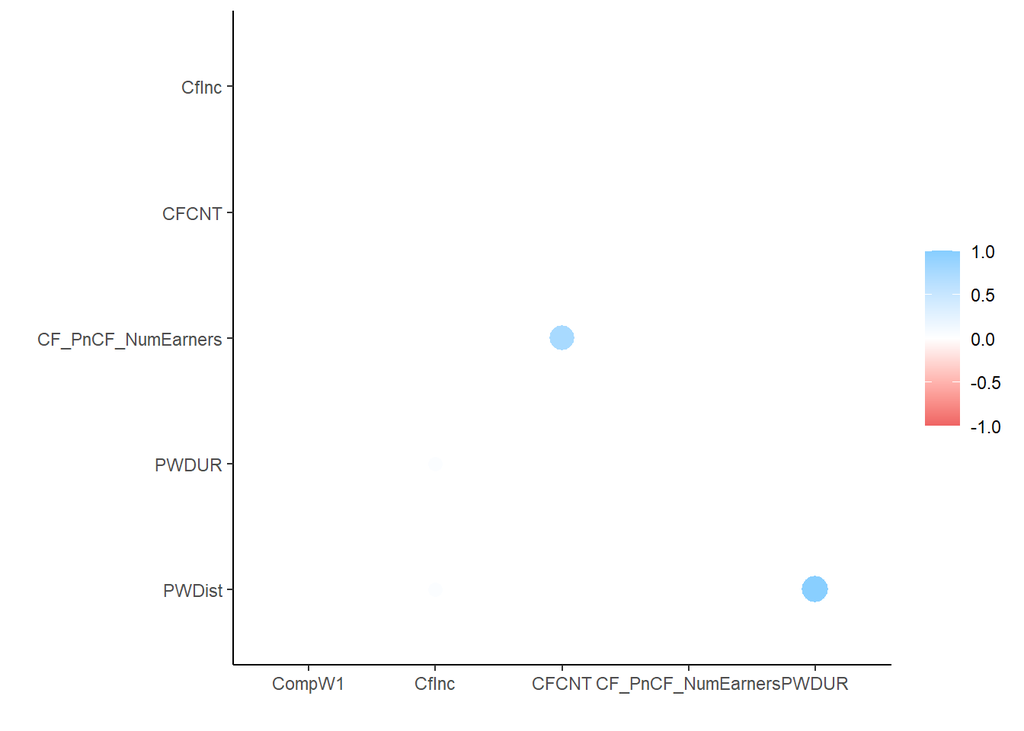

```r
census |>
  select(where(is.numeric)) |>
  correlate(method = "pearson",
            use = "pairwise.complete.obs") |>
  shave() |>
  rplot()
```

By encoding valence using colors and magnitude using size, we can present the same information in a form that we naturally process with greater ease.

The grammar of graphics, formalized by [Leland Wilkinson](https://en.wikipedia.org/wiki/Leland_Wilkinson) in his [book](https://www.google.it/books/edition/The_Grammar_of_Graphics/ZiwLCAAAQBAJ), provides a structured approach to creating statistical plots, similar to how the grammar of data manipulation offers a way to think about data operations. This concept inspired the creation of the {ggplot2} package, which allows for flexible and intuitive plot creation by layering graphical elements. While {ggplot2} requires explicit specification of what and how to plot, making it more verbose than simple plotting functions, it enables the creation of more sophisticated and expressive plots. This approach integrates data manipulation and plotting, allowing for detailed and customized visualizations. As with summary statistics, it’s crucial to consider the scale of measurement when selecting geometric objects for plots, which vary based on whether the plots are univariate, bivariate, or multivariate, and if the variables are categorical or quantitative.

## Univariate plots

Univariate description involves exploring the main attributes of a single variable, typically its central tendency and spread. For quantitative variables, an appropriate geometric object is a histogram, implemented as `geom_hist()`. Using the variable `CfInc` (total income of census family), we have:

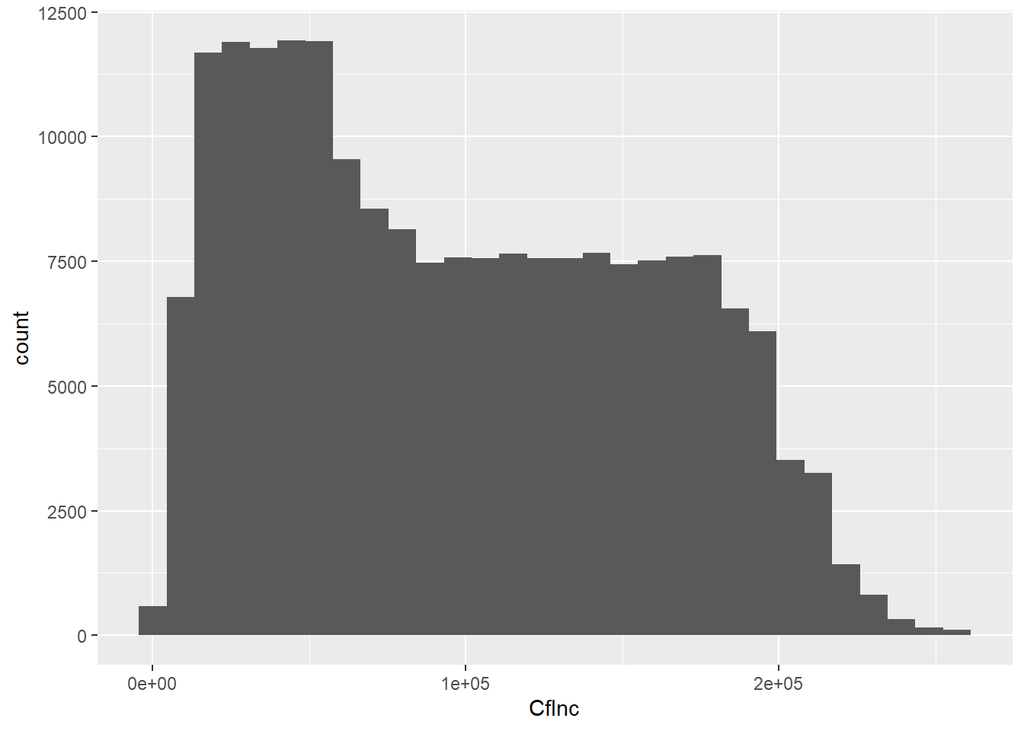

```r
ggplot(data = census,
       aes(x = CfInc)) +
  geom_histogram()
```

A histogram is the number of cases (the *count* of cases) by ranges of values. We only need to encode a single variable (in the example above the `CfInc`), because the “count” on the y-axis is a computed statistic. The default number of bins in `geom_hist()` is 30, but this can be adjusted:

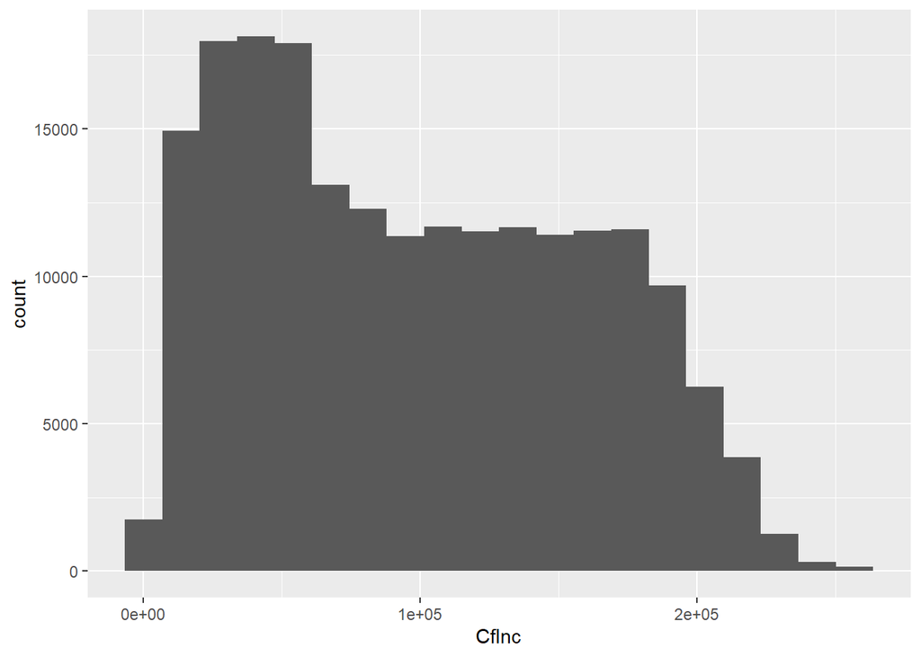

```r
ggplot(data = census,
       aes(x = CfInc)) +
  geom_histogram(bins = 20)
```

An alternative geometric object is a frequency polygon, as shown here:

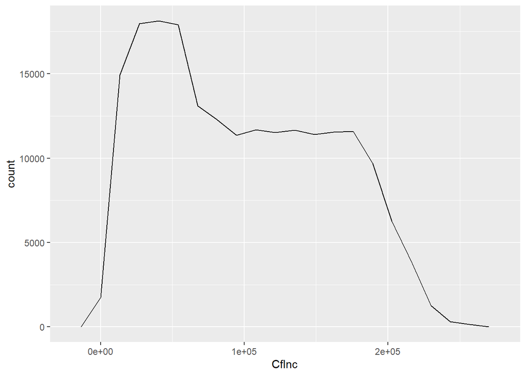

```r
ggplot(data = census,
       aes(x = CfInc)) +
  geom_freqpoly(bins = 20)
```

A density plot is a smoother version of a frequency polygon:

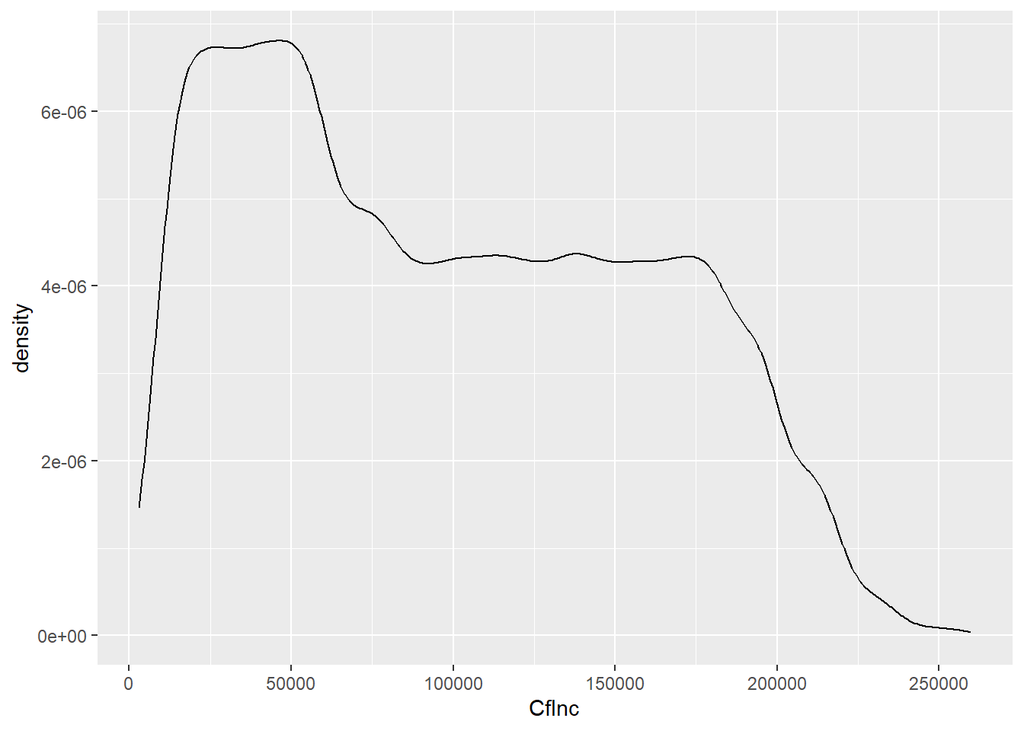

```r
ggplot(data = census,
       aes(x = CfInc)) +
  geom_density(bins = 20) +
 scale_x_continuous(breaks=seq(0,max(census$CfInc),50000))
```

We can use `geom_vline()` to draw vertical lines in the plot (the mean in blue, the median in green):

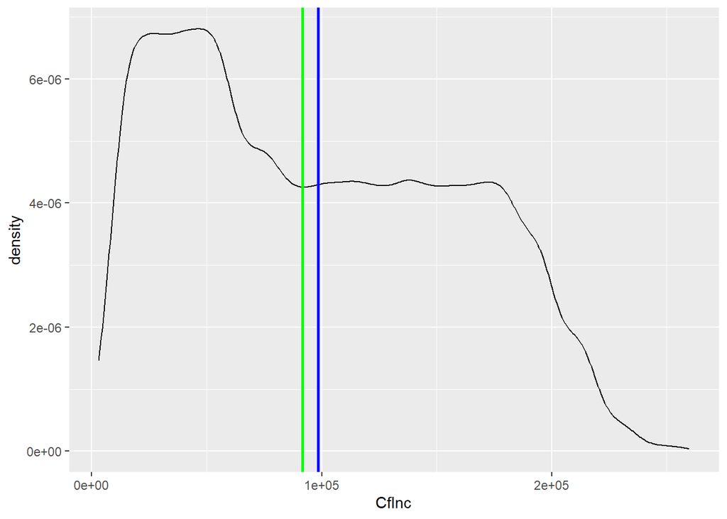

```r
mean_CfInc <- census |>
  pull(CfInc) |>
  mean(na.rm = TRUE)

median_CfInc <- census |>
  pull(CfInc) |>
  median(na.rm = TRUE)

ggplot(data = census,
       aes(x = CfInc)) +
  geom_density(bins = 20) +
  geom_vline(xintercept = mean_CfInc,
             color = "blue",
             size = 1) +
  geom_vline(xintercept = median_CfInc,
             color = "green",
             size = 1)
```

The mean and median of a distribution can differ due to the distribution’s lack of symmetry. The mean is influenced by extreme values or outliers, making it less robust compared to the median, which is more stable as it is not affected by unusual values.

For categorical variables, a bar chart, implemented with `geom_bar()`, is the appropriate geometric object. While bar charts may resemble histograms, they differ in two key ways: the order of categories is not essential, and there are no value ranges, only distinct category labels.

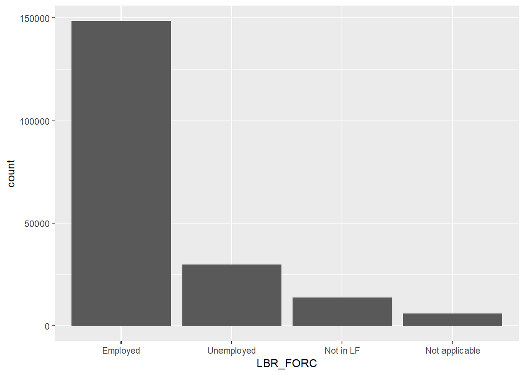

```r
ggplot() +
  geom_bar(data = census,
           aes(x = LBR_FORC))
```

## Bivariate plots

### Two quantitative variables

The scatterplot is a fundamental visualization method for exploring the relationship between two quantitative variables. It maps the values of these variables as points on the x- and y-axes, allowing for the examination of patterns, correlations, and trends between them.

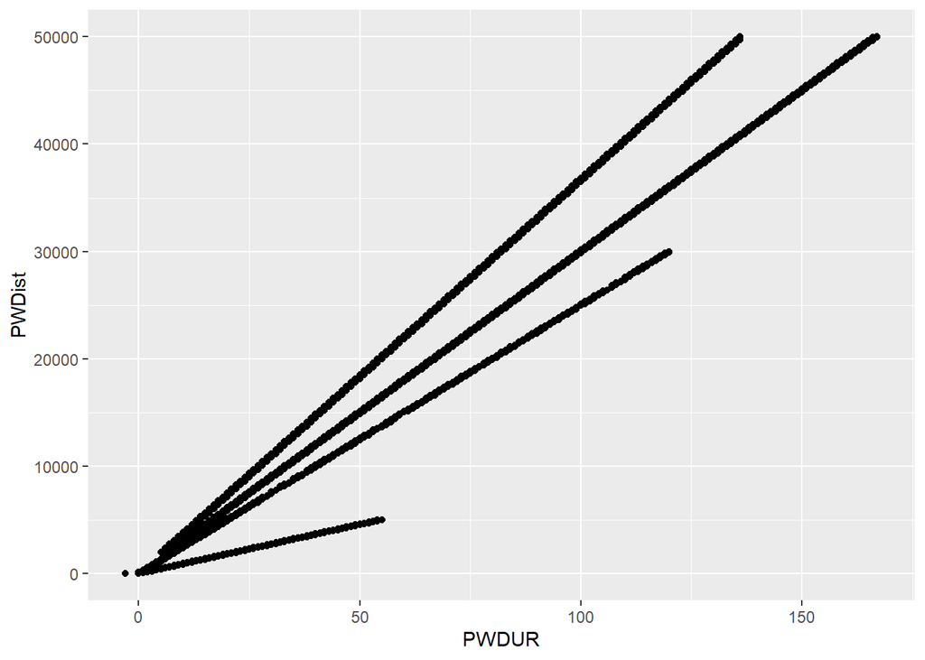

```r
ggplot(data = census) +
  geom_point(aes(x = PWDUR, # Commuting duration
                 y = PWDist) ) # Distance (straight-line) from home to work
```

### Two categorical variables

Two categorical variables can be explored by means of count plots:

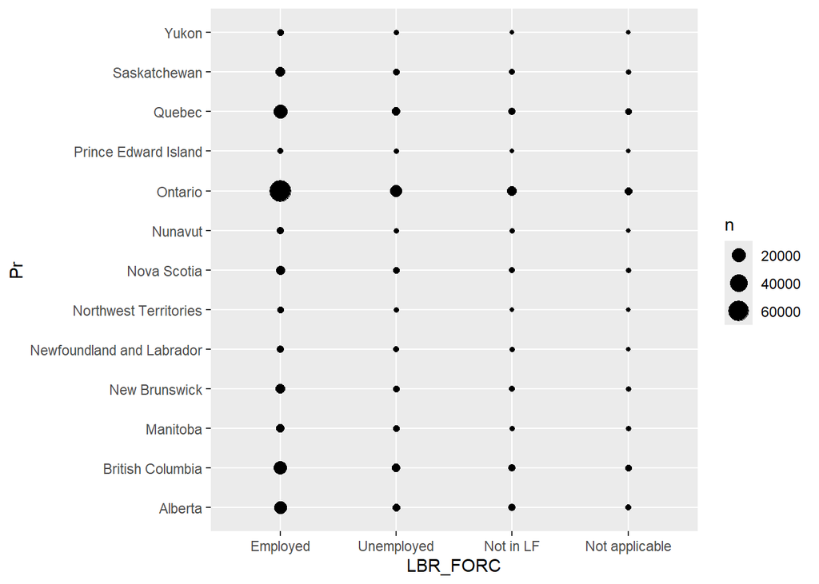

```r
census |>
  ggplot() +
  geom_count(aes(x = LBR_FORC, # province or territory of current residence
               y = Pr)) # employed, unemployed or not in the labour force
```

Count plots are a visual alternative to a cross-tabulation.

### One categorical and one quantitative variable

Visualization techniques can accommodate combinations of one categorical and one quantitative variable, allowing for more nuanced exploration of data. For instance, column plots can map a categorical variable to one axis and a quantitative variable to the other. In this approach, summary statistics like the mean of a quantitative variable (e.g., `CfInc`) are calculated for each category of a categorical variable (e.g., commute mode) and visualized using `geom_col`(). This technique helps to clearly display differences and trends across categories.

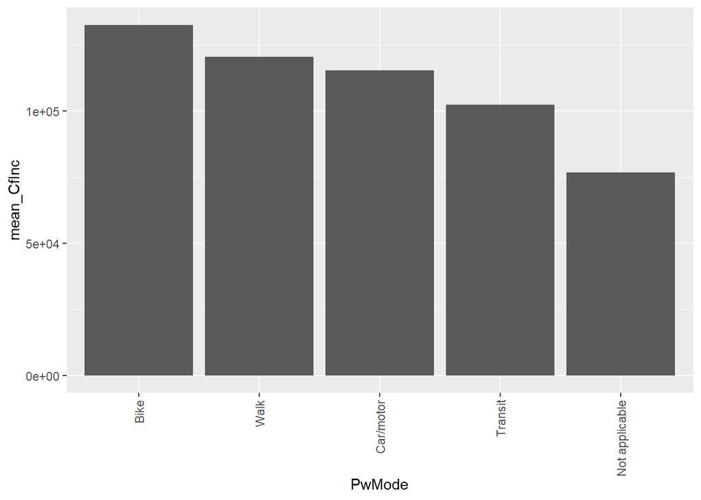

```r
census |>
  group_by(PwMode) |>
  summarize(mean_CfInc = mean(CfInc,
                                 rm.na = TRUE)) |>
  ggplot() +
  geom_col(aes(x = PwMode,
               y = mean_CfInc)) +
  scale_x_discrete(guide = guide_axis(angle = 90))
```

The graph shows that respondents who commute by bicycle have higher household incomes, while people who don’t commute by bicycle tend to have lower household incomes. The boxplot is another valuable visualization technique. It uses a rectangular box to represent the interquartile range (IQR) of a distribution, with lines (whiskers) extending to 1.5 times the IQR to show the range of most data points. Extreme values beyond this range are depicted as individual dots. The median of the distribution is shown as a line within the box. In ggplot2, boxplots are created using `geom_boxplot()`.

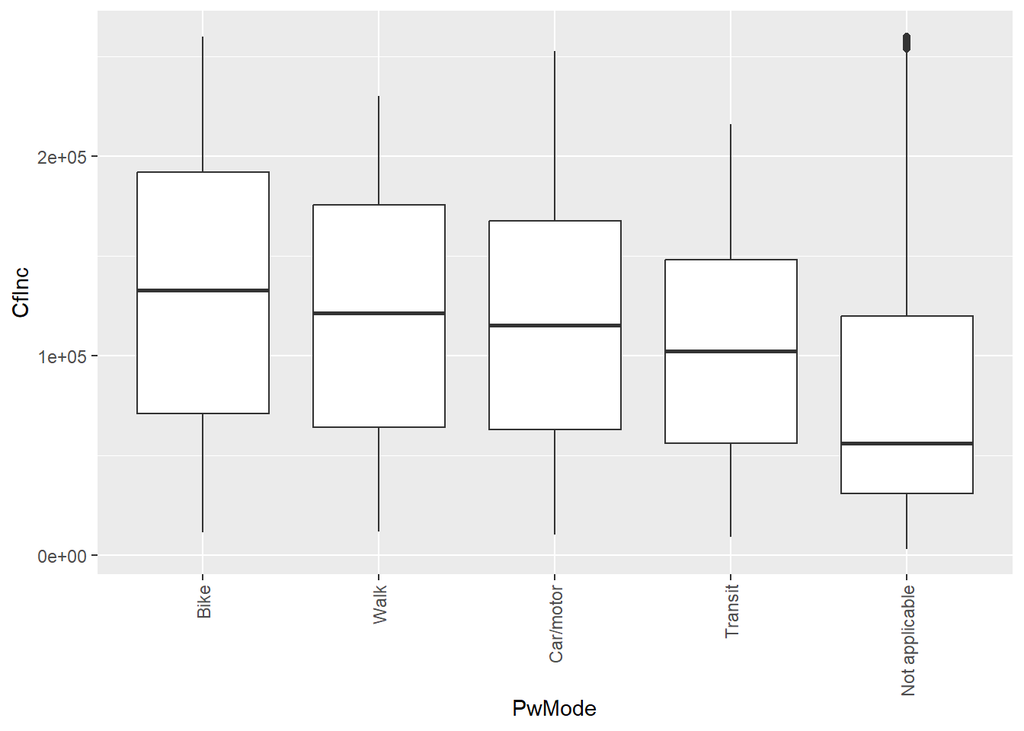

```r
ggplot(data = census) +
  geom_boxplot(aes(x = PwMode,
               y = CfInc)) +
  scale_x_discrete(guide = guide_axis(angle = 90))
```

The boxplot does obscure some of the detail of the underlying distribution of values. Ridge plots address this by plotting the density of the distribution instead:

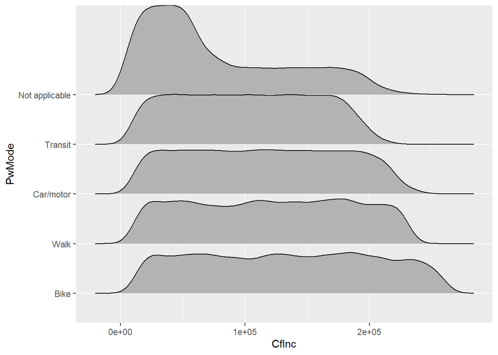

```r
ggplot(data = census) +
  geom_density_ridges(aes(x = CfInc,
                 y = PwMode))
```

## Multivariate description

Higher dimensional visualization can be created by encoding additional variables using available aesthetics. The following chunk of code recreates the boxplot of `PwMode` and `CfInc`, and further maps `LBR_FORC` to color:

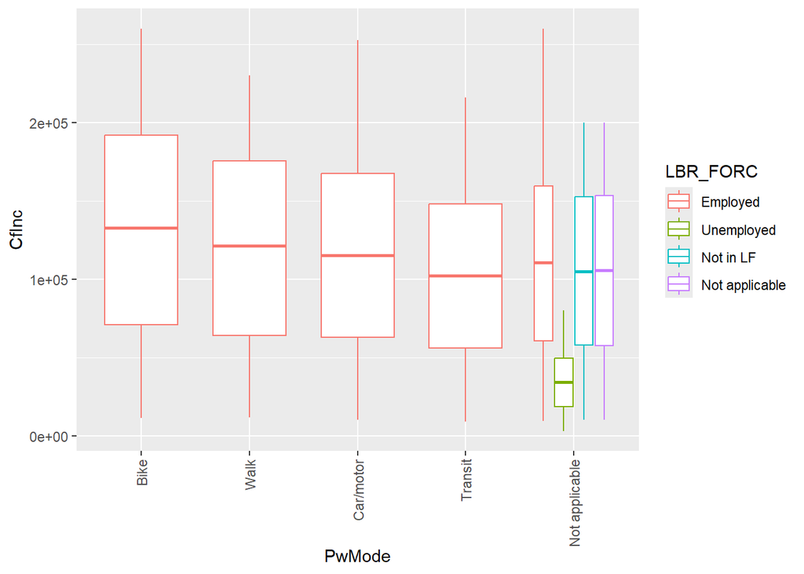

```r
ggplot(data = census) +
  geom_boxplot(aes(x = PwMode,
                 y = CfInc,
                 color = LBR_FORC)) +
scale_x_discrete(guide = guide_axis(angle = 90))
```

This graph shows that the household income of people who commute using active modes tends to be higher. As you need to be employed to commute, the difference variable `LBR_FORC` only appears for those who are not commuting to work (`not applicable`) and shows that unemployed people have the lowest household income.

The following example recreates the scatterplot of `PWDUR` and `PWDist` that we did before, but now adds `PwMode` to plot, encoded to color and shape:

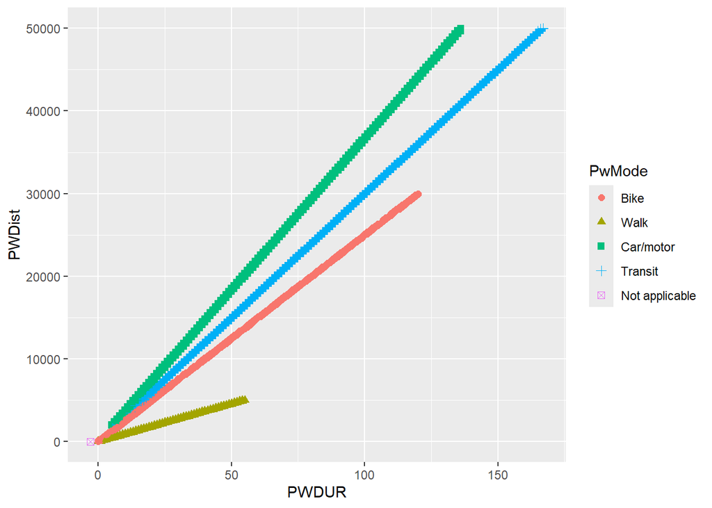

```r
ggplot(data = census) +
  geom_point(aes(x = PWDUR,
                 y = PWDist,
                 color = PwMode,
                 shape = PwMode),
             size = 2)
```